# N741 Homework 8 - ANSWER KEY

Melinda Higgins

May 6, 2019

## Setup code

For this homework you will be working with the Abalone dataset from UCI, see http://archive.ics.uci.edu/ml/datasets/abalone.

There were 3 dimensional measurements made of the abalones: length, diameter and height in mm (millimeters). Length was defined to be the longest length, longer than diameter or height. All measurements should be > 0.

There were also 3 weight component measurements in grams: shucked weight, viscera weight and shell weight, which are all less than the total weight of the abalones. The total whole weight is also provided.

The “sexes” of the abalones in this dataset are:

- “I” for infants (immature)
- “M” for males (adult)
- “F” for females (adult)

We will use unsupervised clustering methods in this homework to see if any of the clusters and components reflect the abalones by sex.

The dataset also includes the number of rings in the shells which, like trees, can be used to determine the age of the abalones where age = rings + 1.5. We will not be using this measure in this homework.

The setup code below:

- reads in the data,
- adds the variable names,
- cleans up the dataset removing cases with typos or illogical measures that do not meet the criteria specified above; and
- the code also does a small random sample of 5% of the cases, giving us about 200+ abalones to work with for this homework exercise.

```r
# view code
knitr::opts_chunk$set(echo = TRUE)

# suppress printing of messages, warnings and errors
knitr::opts_chunk$set(message = FALSE)
knitr::opts_chunk$set(warning = FALSE)
knitr::opts_chunk$set(error = FALSE)

library(dplyr)
library(readr)

# read-in abalone dataset
# abalone <- read_csv("abalone.data", col_names = FALSE)
abalone <- read_csv(url("http://archive.ics.uci.edu/ml/machine-learning-databases/abalone/abalone.data"))
# assign variable names
names(abalone) <- c("sex","length","diameter","height",
                    "wholeWt","shuckedWt","visceraWt","shellWt",
                    "rings")

# cleanup data
# component weights should be less than whole weight
# length is defined to be the longest dimensional measurement
# and all dimensions should be > 0 - there are some 0 heights
abaloneClean <- abalone %>%
  filter(shuckedWt < wholeWt) %>%
  filter(visceraWt < wholeWt) %>%
  filter(diameter < length) %>%
  filter(height < length) %>%
  filter(height > 0)

# take a 5% random sample of 4169 cases
abaloneSample <- abaloneClean %>%
  sample_frac(size = 0.05, replace = FALSE)

# keep 3 dimensions and 3 component weights
# remove sex and number of rings
# number of rings + 1.5 = age of abalone
abaloneKeep <- abaloneSample %>%
  select(length, diameter, height,
         shuckedWt, visceraWt, shellWt)
```

You will use the `abaloneKeep` dataset for this homework exercise, which has about 200+ cases and only has 6 variables: 3 dimensional measures and 3 component weights.

Use the code from the Unsupervised Learning lecture to guide you in this homework - see https://htmlpreview.github.io/?https://github.com/vhertzb/more-supervised-learning/blob/master/More_Supervised_Learning.html - look about half-way down the webpage where Unsupervised Learning begins.

**NOTE: Code is provided below in place to help. REMEMBER to add `{r}` to the code chunks below so they will run as R code chunks in your final homework assignment. The `{r}` was removed to generate the homework assignment document.**

## Cluster Analysis

```r
# Scale the data before clustering
sd.data <- scale(abaloneKeep)
```

PROBLEM 1: Using the scaled data `sd.data` calculate the Euclidean distance between each pair of points

**ANSWER KEY**

```r
# Calculate Euclidean distance between each pair of points
data.dist <- dist(sd.data)
```

PROBLEM 2: Plot the tree, default linkage = ‘complete’. Set `labels = abaloneSample$sex` to get the sex labels for the plot.

**ANSWER KEY**

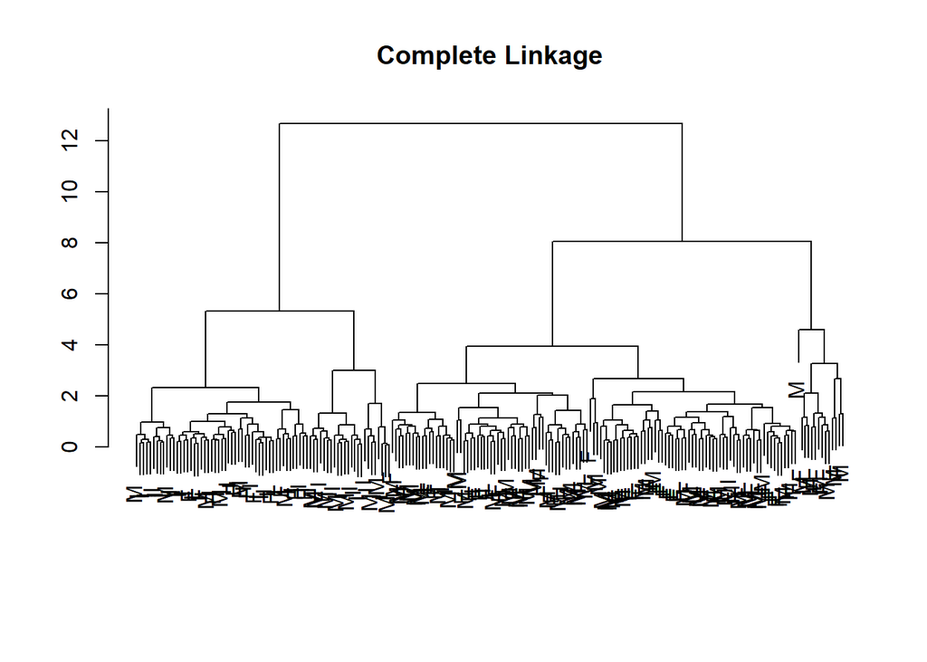

```r
# Plot the tree, default linkage is 'complete'
plot(hclust(data.dist), labels = abaloneSample$sex,
     main = "Complete Linkage", xlab = "",
     sub = "", ylab = "")
```

PROBLEM 3: Plot the tree, using linkage = ‘average’. Set `labels = abaloneSample$sex` to get the sex labels for the plot.

**ANSWER KEY**

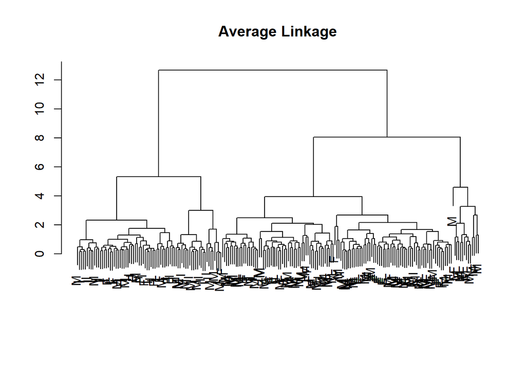

```r
# Plot the tree, using linkage = 'average'
plot(hclust(data.dist),
     method = "average",
     labels = abaloneSample$sex,
     main = "Average Linkage", xlab = "",
     sub = "", ylab = "")
```

PROBLEM 4: Plot the tree, using default linkage = ‘single’. Set `labels = abaloneSample$sex` to get the sex labels for the plot.

**ANSWER KEY**

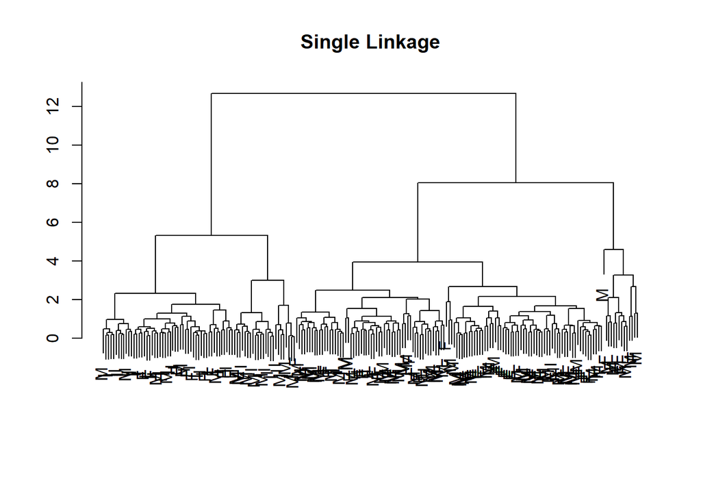

```r
# Plot the tree, using default linkage = 'single'
plot(hclust(data.dist),
     method = "single",
     labels = abaloneSample$sex,
     main = "Single Linkage", xlab = "",
     sub = "", ylab = "")
```

PROBLEM 5: Let’s use complete linkage and cut into 3 clusters. When running the `table()` line of code use `abaloneSample$sex` to compare the original sexes to the clusters `hc.clusters`.

**ANSWER KEY**

```r
hc.out <- hclust(dist(sd.data))
hc.clusters <- cutree(hc.out, 3)
table(hc.clusters, abaloneSample$sex)
```

```
##
## hc.clusters  F  I  M
##           1 11 50 14
##           2 53  9 57
##           3  7  0  7
```

PROBLEM 6: Given the results above:

- which cluster(s) did the best job identifying the infants?
- which cluster(s) found the adults (M and F)?

## K-Means clustering

PROBLEM 7: Run a K-means clustering with K=3 (same as we did above for the hierarchical clustering). Compare the clusters from K-means clustering and the hierarchical clustering `hc.clusters` (using the complete linkage method). How do these clusters compare - similar or not?

**ANSWER KEY**

```r
set.seed(40523)
km.out = kmeans(sd.data, 3, nstart = 20)
km.clusters = km.out$cluster
table(hc.clusters, abaloneSample$sex)
```

```
##
## hc.clusters  F  I  M
##           1 11 50 14
##           2 53  9 57
##           3  7  0  7
```

```r
table(km.clusters, abaloneSample$sex)
```

```
##
## km.clusters  F  I  M
##           1 27 33 29
##           2 42  1 38
##           3  2 25 11
```

So, neither clustering approach does a great job of differentiating the sexes simply through an untargeted, unsupervised approach.

## PCA - Principal Components Analysis

PROBLEM 8: Find the principal components of the normalized data, which are computed using scale = TRUE option. Use `abaloneKeep` as the input dataset.

**ANSWER KEY**

```r
pr.out <- prcomp(abaloneKeep, scale = TRUE)
```

### Plot of the data points on the first 2 PCs

The code to show the “Scores Plot” on the 1st two PCs (principal components) is provided below.

```r
# colors
cols=rainbow(length(unique(abaloneSample$sex)))

# mapping of colors to sex
# blue is #0000FFFF
# light green is #00FF00FF
# red is #FF0000FF
#
# see https://webtools.fineaty.com/ColorInfo/0000FFFF/en/Information-about-the-0000FFFF-color.html
# see https://webtools.fineaty.com/ColorInfo/00FF00FF/en/Information-about-the-00FF00FF-color.html
# see https://webtools.fineaty.com/ColorInfo/FF0000FF/en/Information-about-the-FF0000FF-color.html

table((unique(abaloneSample$sex)), cols)
```

```
##    cols
##     #0000FFFF #00FF00FF #FF0000FF
##   F         0         1         0
##   I         0         0         1
##   M         1         0         0
```

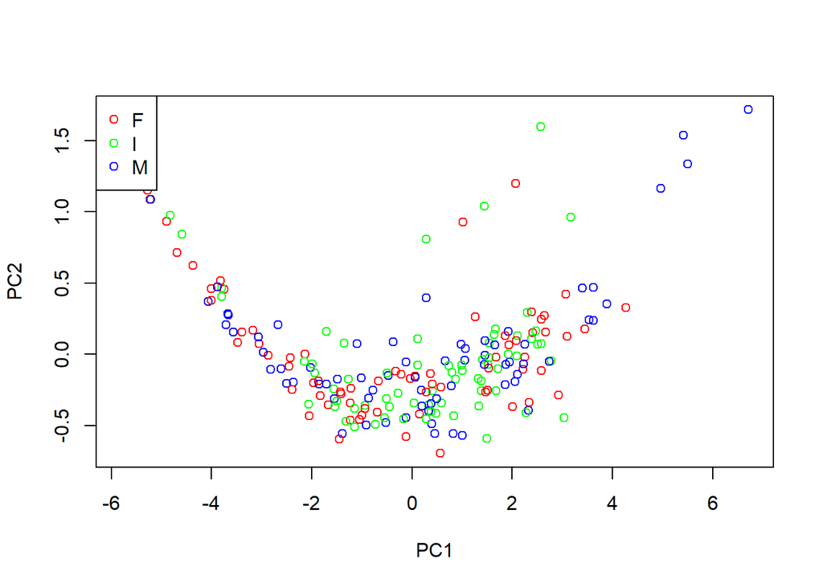

```r
# plot scores
plot(pr.out$x[, 1:2],
     col = cols)
legend(x = "topleft",
       legend = c("F", "I", "M"),
       col = cols, pch = 1)
```

PROBLEM 9: For the “Scores Plot” above, do you see any separation of the 3 sexes by their principal component scores?

*… just answer in your own words here …*

**ANSWER KEY**

Given the plot of the first two PCs, there is no clear separation of the 3 sexes on the principal components.

PROBLEM 10: Look at the summary of the PCA, run the summary of `pr.out`. What percentage of variance is explained by the first 2 principal components?

```r
# look at summary of PCA
summary(pr.out)
```

```
## Importance of components:
##                          PC1     PC2     PC3     PC4     PC5     PC6
## Standard deviation     2.344 0.44648 0.39204 0.28282 0.24268 0.10890
## Proportion of Variance 0.916 0.03322 0.02562 0.01333 0.00982 0.00198
## Cumulative Proportion  0.916 0.94926 0.97488 0.98821 0.99802 1.00000
```

PROBLEM 11: Plot the “Scree” plot

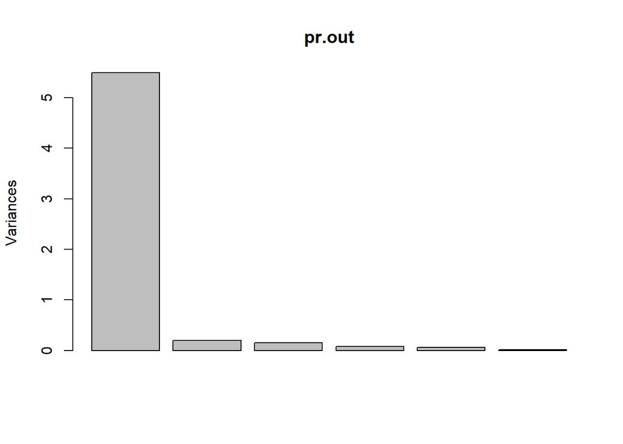

```r
# plot scree plot
plot(pr.out)
```

## MDS - Multidimensional Scaling

PROBLEM 12: Compute the Euclidean distance between each pair of points for `abaloneKeep` (you do not need to scale the data first - just use `abaloneKeep` as is).

```r
# compute distances for abaloneKeep
d <- dist(abaloneKeep)
```

PROBLEM 13: Run `cmdscale()` function to perform a Classical Metric MDS, set `eig-TRUE` and `k=2`. Save the results in an object named `fit`. View the results for `fit`.

```r
# k is the number of principal coordinates we want
# let's use 2
# run cmdscale - classicalmetric MDS
fit <- cmdscale(d, eig=TRUE, k=2)

# view the results
fit
```

```
## $points
##                [,1]          [,2]
##   [1,]  0.386590168  0.0024789581
##   [2,] -0.222197942 -0.0123887411
##   [3,]  0.134330620 -0.0112428561
##   [4,] -0.372936833  0.0472305639
##   [5,] -0.153270416  0.0611233405
##   [6,] -0.113494306 -0.0464190475
##   [7,]  0.134788515 -0.0089204855
##   [8,] -0.331350797  0.0366373447
##   [9,] -0.463255882  0.0124146269
##  [10,]  0.015908636  0.0355068606
##  [11,] -0.052541759  0.0439251442
##  [12,] -1.026886277 -0.1366360535
##  [13,]  0.476384054 -0.0619981658
```

[output cut: 248 more lines]

PROBLEM 14: Plot the MDS fit results, set `labels = abaloneSample$sex`.

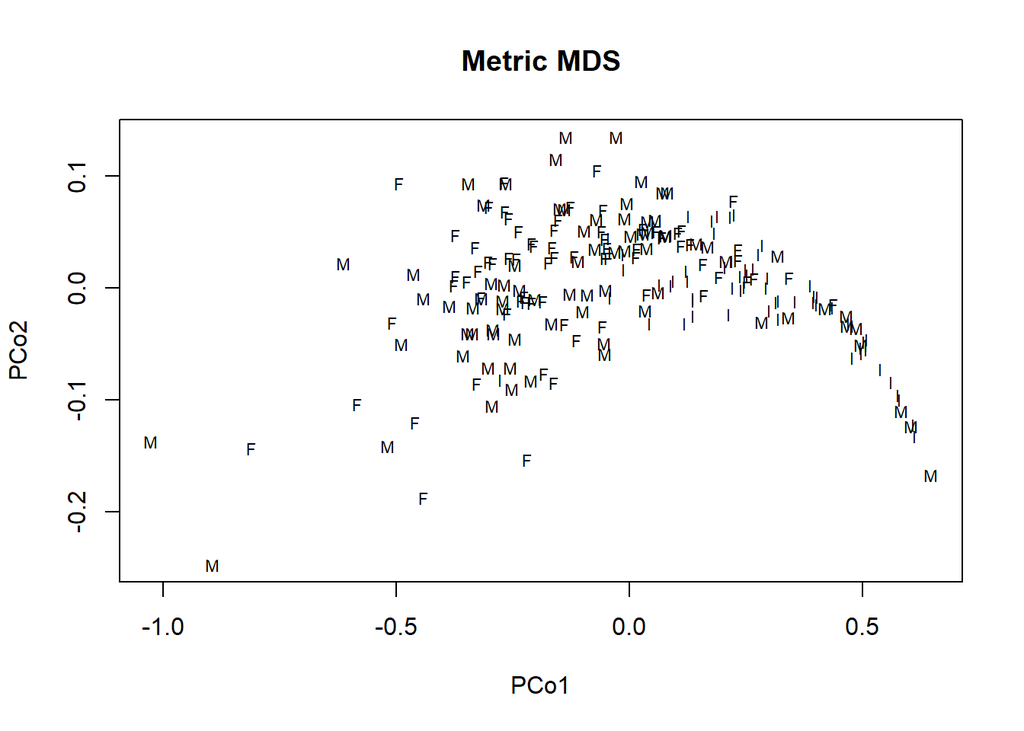

```r
# plot it
x <- fit$points[,1]
y <- fit$points[,2]

plot(x, y, xlab = "PCo1", ylab = "PCo2",
     main = "Metric MDS", type = "n")
text(x, y, labels = abaloneSample$sex, cex = 0.7)
```

Based on this plot, again the separation is not great between the 3 sexes, although it does look like slightly more infants are plotting towards the upper end (right side) of the plot (along PCo1).